# Intro Stats to Intro Psych Students

Brian Holt

January 3, 2020

# Preliminary remarks

I have to give thanks to Richard McElreath’s well received book, Statistical Rethinking[^1], because of his clarity of writing, thinking, and teaching, I’m compelled to do my best to help new students learn the language of statistics without having massive backgrounds in math.

This has it’s dangers because statistics is applied probability, which has a venerated history in mathematics, and I must be careful to do more good than harm.

[figure not shown]

Kitty gif just because

McElreath begins in earnest by writing about an example to estimate how much of a planet is covered by water. Imagine sending a probe out in space and you only have a short period of time to estimate the water coverage on a planet.

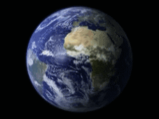

And also say you can simply detect the presence of water, or not. So, you randomly pick 9 (an arbitrary number here for example) observations and you observe:

| Water | Land |
| --- | --- |
| 6 | 3 |

A word on probability and statistics. It’s hard. And intimidating.

And people will have various amounts of historical trauma with math, math teachers, and other studetns.

I don’t want you to feel intimidated.

I want you to feel empowered.

I’m going to go slow to help you see why this matters.

Assuming you have perfect detection and data, here are a few questions related to statistics and inference:

1. What is the probability of finding this result of 6 out of 9 observations as water?
2. How does this tell us anything about how much water really is covering the planet?

McElreath goes through a methodical and gentle introduction how one should think about this problem, but we are going to simplify this example and change to some psychological context.

## A simpler example using introverts

Instead of thinking in terms of space exploration, let’s switch to a more psychological example, and I’ll reduce the size of observations to keep it very simple.

Let’s say you are observing whether an introvert will ask someone out on a date.

[figure not shown]

| Ask them out |  |  |
| --- | --- | --- |
| No | Yes | Total |
| 2 | 1 | 3 |

```
## observations
##  no yes Sum
##   2   1   3
```

So, probability is really just counting. And it is helpful to show what is actually being counted.

To do this, you should think of all the ways that could possibly be observed in this set of 3 observations.

You might be wondering why you need to count all of these ways as they seem to amount to the same thing.

But now you need to think about all the possible ways 3 opportunities could go.  
They could be from one extreme of asking someone out all 3 opportunities, or none at all. They could be:

| Group 1 |  | Group 2 |
| --- | --- | --- |
| Y,Y,Y |  | N,N,N |
| Y,Y,N |  | N,N,Y |
| Y,N,Y |  | N,Y,N |
| N,Y,Y |  | Y,N,N |

```
## [1] 0.375
```

[^1]: Richard McElreath (2020), Statistical Rethinking, CRC Press, URL: https://xcelab.net/rm/statistical-rethinking/